# Over-Fitting and Model Tuning

May 5, 2017

# Get the Book

There is an excellent book called Applied Predictive Modeling and if you are interested in machine learning and statistics, then check it out at the link. I am going through examples from chapter 4 while manipulating the examples a bit as I explore them.

```r
set.seed(1)
library(AppliedPredictiveModeling)
library(caret)
library(caTools)
library(ggplot2)
library(ggthemes)
```

# Overfitting

```
Description

These data contain two predictors measured for 208 samples. Of these, 111 samples are labeled as Class1 and the remaining 97 are Class2.
```

```r
data(twoClassData)

str(predictors)
```

```
## 'data.frame':    208 obs. of  2 variables:
##  $ PredictorA: num  0.158 0.655 0.706 0.199 0.395 ...
##  $ PredictorB: num  0.1609 0.4918 0.6333 0.0881 0.4152 ...
```

```r
str(classes)
```

```
##  Factor w/ 2 levels "Class1","Class2": 2 2 2 2 2 2 2 2 2 2 ...
```

## Functions For Sampling

The base R function `sample` creates random splits of the data. Stratified samples based on classes can be created by using the `createDataPartition` function in `caret`. The `sample.split` function in `caTools` splits data from vector Y into two sets in predefined ratio while preserving relative ratios of different labels in Y.

```r
trainingRows = createDataPartition(classes,
                                   p = .8,
                                   list = FALSE)

head(trainingRows)
```

```
##      Resample1
## [1,]         1
## [2,]         2
## [3,]         3
## [4,]         4
## [5,]         5
## [6,]         6
```

```r
# Subset data into objects for training
trainPredictors = predictors[trainingRows,]
trainClasses = classes[trainingRows]


testPredictors = predictors[-trainingRows,]
testClasses = classes[-trainingRows]


str(trainPredictors)
```

```
## 'data.frame':    167 obs. of  2 variables:
##  $ PredictorA: num  0.158 0.655 0.706 0.199 0.395 ...
##  $ PredictorB: num  0.1609 0.4918 0.6333 0.0881 0.4152 ...
```

```r
str(testPredictors)
```

```
## 'data.frame':    41 obs. of  2 variables:
##  $ PredictorA: num  0.0658 0.1056 0.2909 0.4129 0.0472 ...
##  $ PredictorB: num  0.1786 0.0801 0.3021 0.2869 0.0414 ...
```

To generate a test set using maximum dissimilarity sampling, the caret function `maxDissim` can be used to sequentially sample the data. This was taken from the help file for maxDissim.

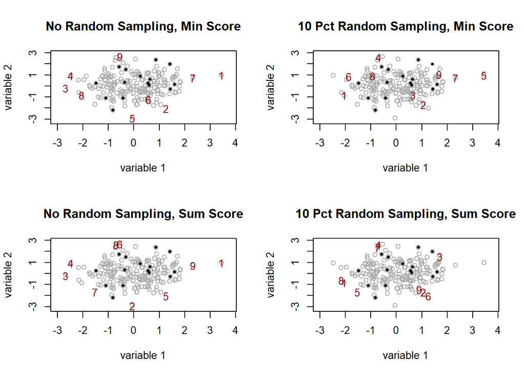

```r
example <- function(pct = 1, obj = minDiss, ...)
{
  tmp <- matrix(rnorm(200 * 2), nrow = 200)

  ## start with 15 data points
  start <- sample(1:dim(tmp)[1], 15)
  base <- tmp[start,]
  pool <- tmp[-start,]

  ## select 9 for addition
  newSamp <- maxDissim(
                       base, pool,
                       n = 9,
                       randomFrac = pct, obj = obj, ...)

  allSamp <- c(start, newSamp)

  plot(
       tmp[-newSamp,],
       xlim = extendrange(tmp[,1]), ylim = extendrange(tmp[,2]),
       col = "darkgrey",
       xlab = "variable 1", ylab = "variable 2")
  points(base, pch = 16, cex = .7)

  for(i in seq(along = newSamp))
    points(
           pool[newSamp[i],1],
           pool[newSamp[i],2],
           pch = paste(i), col = "darkred")
}

par(mfrow=c(2,2))

set.seed(414)
example(1, minDiss)
title("No Random Sampling, Min Score")

set.seed(414)
example(.1, minDiss)
title("10 Pct Random Sampling, Min Score")

set.seed(414)
example(1, sumDiss)
title("No Random Sampling, Sum Score")

set.seed(414)
example(.1, sumDiss)
title("10 Pct Random Sampling, Sum Score")
```

# Resampling

You can use the function `createDataPartition` again with the argument `times` to generate multiple splits.

```r
repeatedSplits = createDataPartition(trainClasses,
                                     p = 0.80,
                                     times = 3)

str(repeatedSplits)
```

```
## List of 3
##  $ Resample1: int [1:135] 1 2 5 6 9 10 12 13 14 15 ...
##  $ Resample2: int [1:135] 1 3 4 5 6 8 9 10 11 12 ...
##  $ Resample3: int [1:135] 1 2 3 5 6 7 8 9 10 12 ...
```

`caret` has the function `createResamples` (for bootstrapping), `createFolds` (for *k*-fold cross-calidation) and `createMultiFolds` (for repeated cross-validation). To create indicators for 10-fold cross-validation,

```r
cvSplits = createFolds(trainClasses, k = 10,
                       returnTrain = TRUE)

str(cvSplits)
```

```
## List of 10
##  $ Fold01: int [1:150] 3 4 5 6 7 8 9 10 12 13 ...
##  $ Fold02: int [1:151] 1 2 3 4 6 7 8 9 10 11 ...
##  $ Fold03: int [1:150] 1 2 3 4 5 6 7 8 9 10 ...
##  $ Fold04: int [1:150] 1 2 3 4 5 6 7 8 9 11 ...
##  $ Fold05: int [1:150] 1 2 3 4 5 6 8 9 10 11 ...
##  $ Fold06: int [1:150] 1 2 3 4 5 6 7 8 10 11 ...
##  $ Fold07: int [1:150] 1 2 3 4 5 6 7 9 10 11 ...
##  $ Fold08: int [1:152] 1 2 3 4 5 6 7 8 9 10 ...
##  $ Fold09: int [1:150] 1 2 4 5 6 7 8 9 10 11 ...
##  $ Fold10: int [1:150] 1 2 3 5 7 8 9 10 11 12 ...
```

# Basic Model Building in R

Models in *R* have to general formulations. The first involves explicitly expressing the model as a a formula. For example, `price ~ desirability + availability` states that desirability and availability are predictors while price is the response. Another way is to pue the model into matrix form like below.

```
Description

k-nearest neighbour classification that can return class votes for all classes.
```

## Simple k-nn Model

For `knn3`, we can estimate the 5-nearest neighborhood model with:

```r
trainPredictors = as.matrix(trainPredictors)
knnFit = knn3(x = trainPredictors, y = trainClasses, k = 5)
knnFit
```

```
## 5-nearest neighbor classification model
## Training set class distribution:
##
## Class1 Class2
##     89     78
```

## Prediction

Now, the model is ready to predict new samples.

```r
testPredictions = predict(knnFit,
                          newdata = testPredictors,
                          type = "class")
```

Here is a plot of our classification solution.

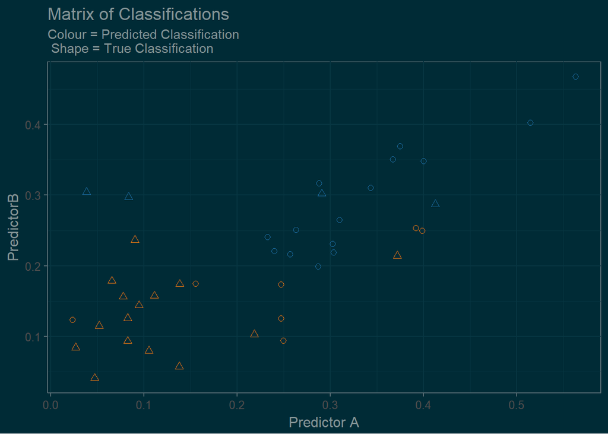

```r
gg=ggplot(testPredictors, aes(x = PredictorA, y = PredictorB, colour = testPredictions)) +
  geom_point(cex = 2, shape = testClasses) +
  scale_color_tableau(guide = FALSE) +
  theme_solarized(light = FALSE) +
  xlab("Predictor A") +
  ggtitle("Matrix of Classifications", sub = "Colour = Predicted Classification\n Shape = True Classification")

gg
```

# Determination of Tuning Parameters

The `e1071` package contains the `tune` function, which can evaluate four types of models across a range of parameters. Simliarly, the `errorforest` function in the `ipred` package can resample single models. The `train` function in the `caret` package has built-in modules for 144 models and includes capabilities for different resampling methods, performance measures, and algorithms for choosing the best model from the profile. This function also has capabilities for paralell processing so that he resampled model fits can be executed across multiple computers or processors.

For the credit scoring dat, a radial bais function (RBF) kernel function was used. This kernel function has an additional tuning parameter associated with it denoted as $\sigma$ which impacts the smoothness of the decision boundary.

To tune an SVM model using the credit scoring training set samples, the `train` function can be used. Both the training set predictors and outcome are contained in an R data frame called `GermanCreditTrain`.

## Import the Data

```r
data("GermanCredit")
splitData = sample.split(GermanCredit, SplitRatio = .8)
GermanCreditTrain = GermanCredit[splitData,]
GermanCreditTest = GermanCredit[-splitData,]
str(GermanCredit)
```

```
## 'data.frame':    1000 obs. of  62 variables:
##  $ Duration                              : int  6 48 12 42 24 36 24 36 12 30 ...
##  $ Amount                                : int  1169 5951 2096 7882 4870 9055 2835 6948 3059 5234 ...
##  $ InstallmentRatePercentage             : int  4 2 2 2 3 2 3 2 2 4 ...
##  $ ResidenceDuration                     : int  4 2 3 4 4 4 4 2 4 2 ...
##  $ Age                                   : int  67 22 49 45 53 35 53 35 61 28 ...
##  $ NumberExistingCredits                 : int  2 1 1 1 2 1 1 1 1 2 ...
##  $ NumberPeopleMaintenance               : int  1 1 2 2 2 2 1 1 1 1 ...
##  $ Telephone                             : num  0 1 1 1 1 0 1 0 1 1 ...
##  $ ForeignWorker                         : num  1 1 1 1 1 1 1 1 1 1 ...
##  $ Class                                 : Factor w/ 2 levels "Bad","Good": 2 1 2 2 1 2 2 2 2 1 ...
##  $ CheckingAccountStatus.lt.0            : num  1 0 0 1 1 0 0 0 0 0 ...
##  $ CheckingAccountStatus.0.to.200        : num  0 1 0 0 0 0 0 1 0 1 ...
##  $ CheckingAccountStatus.gt.200          : num  0 0 0 0 0 0 0 0 0 0 ...
##  $ CheckingAccountStatus.none            : num  0 0 1 0 0 1 1 0 1 0 ...
```

[output cut: 48 more lines]

## Basics

We’ll use all the predictors so the formula will be `Class ~ .`.

```r
svmFit = train(Class ~ .,
               dat = GermanCreditTrain,
               method = "svmRadial")

pred=predict(svmFit, GermanCreditTest)
```

We can see that the confustion matrix shows we did a pretty bad job at classifying everything. Let’s improve this by tuning the model

```r
print("Confusion Matrix")
```

```
## [1] "Confusion Matrix"
```

```r
table(GermanCreditTest$Class, pred)
```

```
##       pred
##        Bad Good
##   Bad    1  299
##   Good   0  699
```

```r
accuracy = sum(pred==GermanCreditTest$Class)/length(pred)
paste0("Accuracy = ", round(accuracy*100, 2), "%")
```

```
## [1] "Accuracy = 70.07%"
```

Next, let’s clean the data up and use the `trainControl` function to tune the model.

```r
tc = trainControl(method = "repeatedcv", repeats = 5, classProbs = TRUE)

svmFit <- train(Class ~ ., data = GermanCreditTrain,
                method = "svmRadial",
                preProc = c("center", "scale"),
                tuneLength = 10,
                trControl = tc)


svmFit
```

```
## Support Vector Machines with Radial Basis Function Kernel
##
## 790 samples
##  61 predictor
##   2 classes: 'Bad', 'Good'
##
## Pre-processing: centered (61), scaled (61)
## Resampling: Cross-Validated (10 fold, repeated 5 times)
## Summary of sample sizes: 711, 711, 711, 711, 711, 710, ...
## Resampling results across tuning parameters:
##
##   C       Accuracy   Kappa
##     0.25  0.7562608  0.4074525
##     0.50  0.7565043  0.4032836
##     1.00  0.7620612  0.3963072
##     2.00  0.7643205  0.3958102
##     4.00  0.7557156  0.3637664
##     8.00  0.7529436  0.3463912
##    16.00  0.7493737  0.3285791
##    32.00  0.7422722  0.3078762
##    64.00  0.7344206  0.2871061
##   128.00  0.7344304  0.2849843
##
## Tuning parameter 'sigma' was held constant at a value of 0.01017259
## Accuracy was used to select the optimal model using  the largest value.
## The final values used for the model were sigma = 0.01017259 and C = 2.
```

The `plot` method can be used to visualize the performance profile.

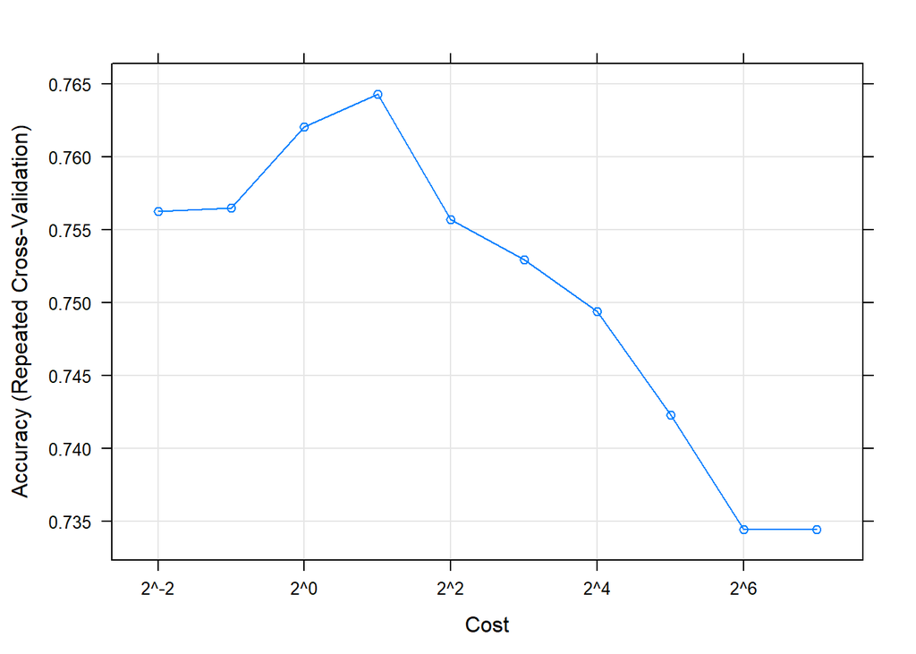

```r
plot(svmFit, scales = list(x = list(log = 2)))
```

To predict new samples with this model, the `predict` method is called.

```r
pred = predict(svmFit, GermanCreditTest)
head(pred)
```

```
## [1] Bad  Good Good Bad  Good Good
## Levels: Bad Good
```

And we can summarize our results by creating a table between the predicted values and the true values. Values along the diagonal are correct predictions.

```r
print("Confusion Matrix")
```

```
## [1] "Confusion Matrix"
```

```r
table(GermanCreditTest$Class, pred)
```

```
##       pred
##        Bad Good
##   Bad  205   95
##   Good  33  666
```

```r
accuracy = sum(pred==GermanCreditTest$Class)/length(pred)
paste0("Accuracy = ", round(accuracy*100, 2), "%")
```

```
## [1] "Accuracy = 87.19%"
```

We can predict probabilities as well.

```r
predictedProbs = predict(svmFit,
                         GermanCreditTest,
                         type = "prob")

head(predictedProbs)
```

```
##          Bad      Good
## 1 0.67956624 0.3204338
## 2 0.08997445 0.9100256
## 3 0.18595932 0.8140407
## 4 0.74013731 0.2598627
## 5 0.17501374 0.8249863
## 6 0.08366572 0.9163343
```

# Between-Model Comparisons

Next, we’ll use a generalized linear model or `glm` This process is exactly the same.

```r
tc = trainControl(method = "repeatedcv", repeats = 5)

logReg <- train(Class ~ .,
                data = GermanCreditTrain,
                method = "glm",
                trControl = tc)
logReg
```

```
## Generalized Linear Model
##
## 790 samples
##  61 predictor
##   2 classes: 'Bad', 'Good'
##
## No pre-processing
## Resampling: Cross-Validated (10 fold, repeated 5 times)
## Summary of sample sizes: 711, 710, 711, 712, 710, 711, ...
## Resampling results:
##
##   Accuracy   Kappa
##   0.7655983  0.4279391
```

We can compare these two models based on their cross-validation statistics, the `resamples` function can be used with models that share a common set of resampled data sets.

The *p*-values for the model comparisons are large.

```r
resamp = resamples(list(SVM = svmFit, Logistic = logReg))
summary(resamp)
```

```
##
## Call:
## summary.resamples(object = resamp)
##
## Models: SVM, Logistic
## Number of resamples: 50
##
## Accuracy
##               Min.   1st Qu.    Median      Mean   3rd Qu.      Max. NA's
## SVM      0.6835443 0.7341772 0.7594937 0.7643205 0.7974684 0.8717949    0
## Logistic 0.6329114 0.7444012 0.7609968 0.7655983 0.7943038 0.8589744    0
##
## Kappa
##                Min.   1st Qu.    Median      Mean   3rd Qu.      Max. NA's
## SVM      0.18489476 0.3195823 0.3959759 0.3958102 0.4719799 0.6596859    0
## Logistic 0.07806841 0.3720191 0.4246838 0.4279391 0.4934039 0.6570743    0
```

The *p*-values for the model comparisons (below) are large (0.8808 for accuracy and .1379 for Kappa), which indicates that the models fail to show any difference in performance.

```r
summary(diff(resamp))
```

```
##
## Call:
## summary.diff.resamples(object = diff(resamp))
##
## p-value adjustment: bonferroni
## Upper diagonal: estimates of the difference
## Lower diagonal: p-value for H0: difference = 0
##
## Accuracy
##          SVM    Logistic
## SVM             -0.001278
## Logistic 0.8808
##
## Kappa
##          SVM    Logistic
## SVM             -0.03213
## Logistic 0.1379
```

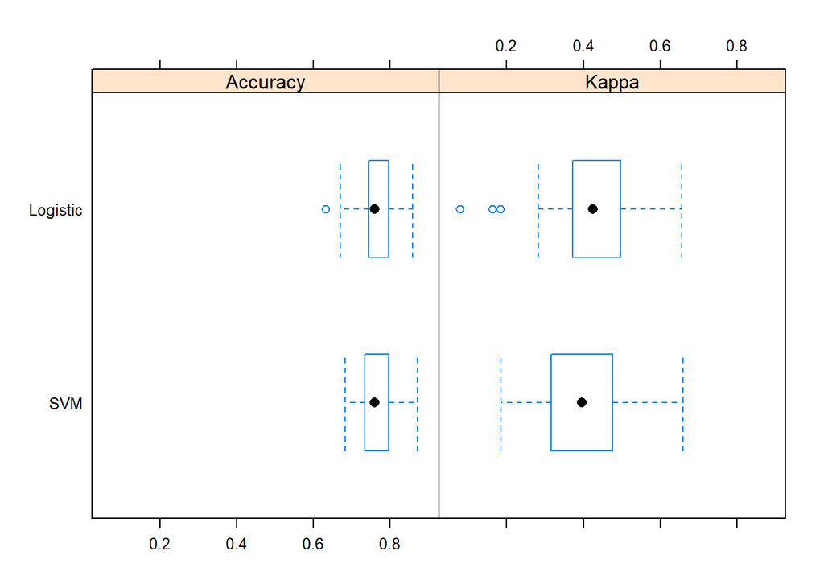

```r
# boxplots of results
bwplot(resamp)
```

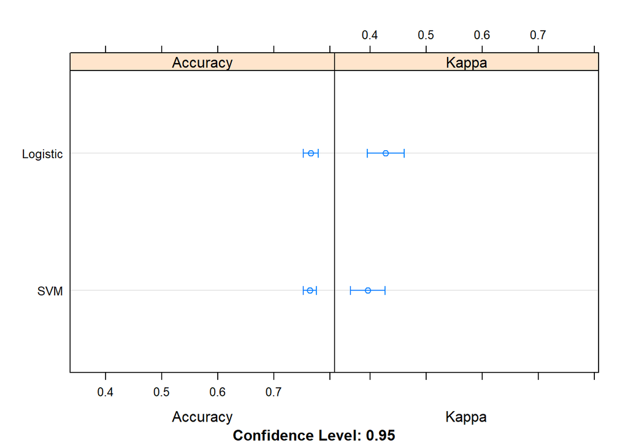

```r
# dot plots of results
dotplot(resamp)
```